# Part II - (Prosper Loan Dataset Explanatory Visualization)

## by (Joshua Enam Semanyoh)

## Investigation Overview

> The goal of the presentation is to communicate the effect of specific loan features such as original loan amount, prosper rating and term on a borrower's APR.

The key insights in this presentation are:

> 1. A distribution of borrower APR.
> 2. A distribution of original loan amount.
> 3. A plot showing the relationship between borrower APR and loan amount.
> 4. A plot showing the relationship between APR and Prosper rating.
> 5. Faceted plots showing the effect of term on the relationship between APR and loan amount.
> 6. Faceted plots showing the effect of prosper rating on relationship between borrower APR and loan amount.
> 7. A plot exploring the relationship between borrower APR, prosper rating and term.

## Dataset Overview

> This data set contains 113,937 loans with 81 variables on each loan; including loan amount, borrower rate (or interest rate), current loan status, borrower income, employment status, listing category, term, prosper rating and many other variables. For this presentation the shape of the dataframe is (84852, 7) as a result of data wrangling and removing of outliers during exploration for efficient analysis and visualization.

## (Distribution of Borrower APR)

> The plot appears to be multimodal. Close to 0.1 there is a small peak, right on both sides of 0.2 there are two more peaks and another peak close to 0.3 mark. There is a very high peak at 0.36. The plot shows that very few Borrower APRs are more than 0.4.

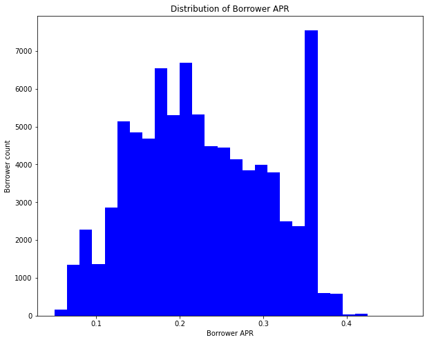

## (Distribution of Original Loan Amount)

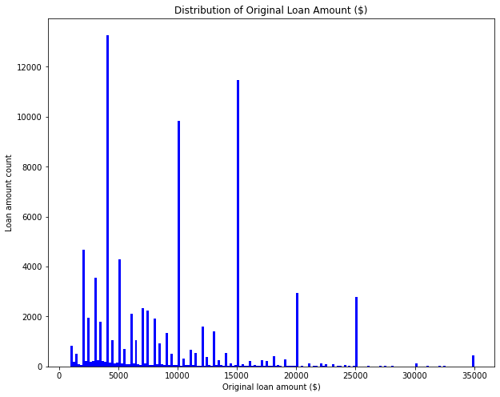

## (Relationship between Borrower APR and Loan Amount)

> From the plot we see that as the loan amount increases the borrower APR range becomes smaller. We observe that loan amounts between 30000 and 35000 have an APR between the range of 0.10 and 0.20.

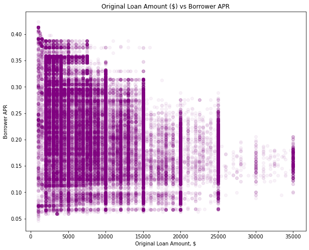

## (Relationship between Borrower APR and Prosper Rating)

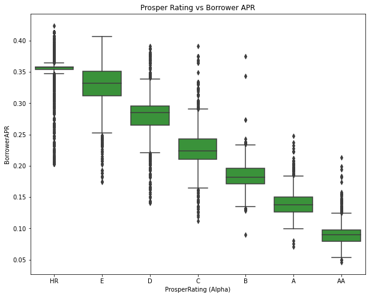

## (Term Effect on Loan Amount and Borrower APR )

> Overall, the borrower APR range is observed to still reduce as the loan amount increases for all terms. However, for term 60 loans the borrower APR range is seen to be smaller even for smaller loan amounts when compared to terms 36 and 12.

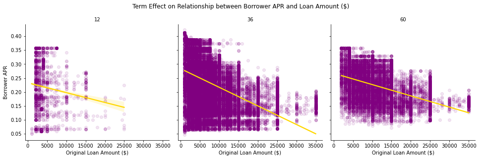

## (Effect of Prosper rating on Loan Amount and Borrower APR)

> It is observed that improving Prosper rating (from HR to AA) results in higher loan amounts and improving (lower) borrower APR. However, we also observe that the correlation between the APR and loan amount becomes slightly positive for A and AA ratings, meaning the APR is likely to increase for people with these ratings when they are taking very high loans. Even then, the APR for A and AA ratings are still the least.

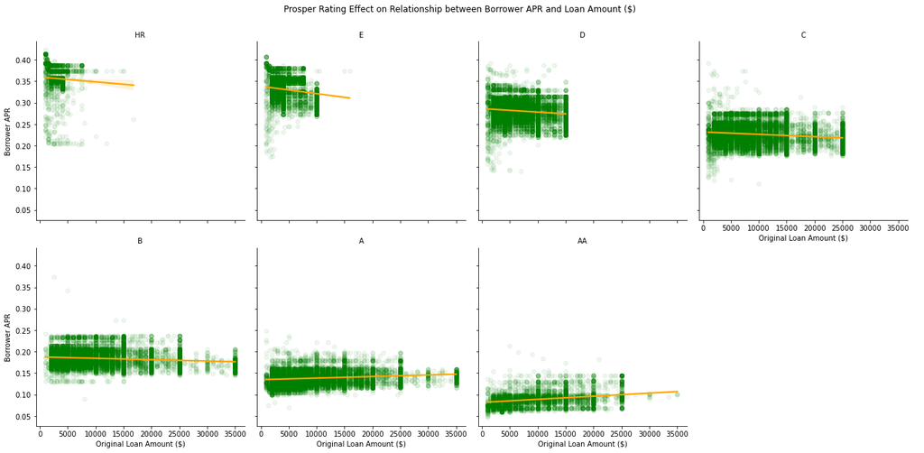

## (Effect of Term on relationship between Prosper Rating and Borrower APR)

> We observe that the borrower APR decreases with the increasing loan term for borrowers with HR to C ratings. However, for people with B to AA ratings, the borrower APR increases with increasing loan term.

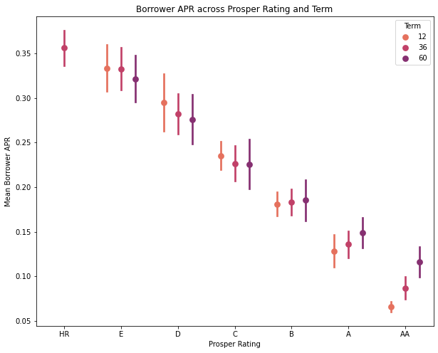